# w2ex4

Robert Satzger

3/9/2023

# Exercise 4. Military Coups

**a)** First, we test for collinearity between the explanatory variables in the dataset.

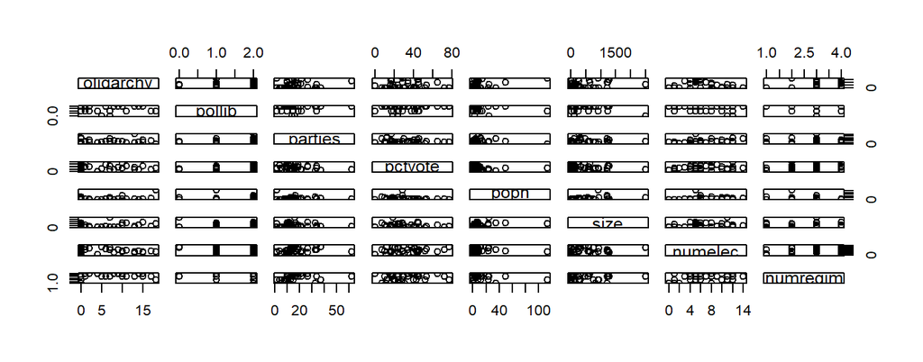

```r
library()
coups <- read.table("data/coups.txt", header = T)
pairs(coups[,-1])
```

There is no clear relationship between any of the explanatory variables. Thus, we perform the Poisson regression with the entire dataset.

Since we want to investigate the significance of the explanatory variables to model performance, we will treat all variables as continuous. This ensures that we obtain coefficients and significance scores for the factor variable (e.g., pollib) rather than its levels.

```r
coupsglm <- glm(miltcoup~., family = poisson, data = coups)
summary(coupsglm)
```

```
##
## Call:
## glm(formula = miltcoup ~ ., family = poisson, data = coups)
##
## Deviance Residuals:
##    Min      1Q  Median      3Q     Max
## -1.344  -0.954  -0.259   0.391   1.695
##
## Coefficients:
##              Estimate Std. Error z value Pr(>|z|)
## (Intercept) -0.510269   0.905330   -0.56   0.5730
## oligarchy    0.073081   0.034596    2.11   0.0346 *
## pollib      -0.712978   0.272563   -2.62   0.0089 **
## parties      0.030774   0.011187    2.75   0.0059 **
## pctvote      0.013872   0.009753    1.42   0.1549
## popn         0.009343   0.006595    1.42   0.1566
## size        -0.000190   0.000248   -0.76   0.4445
## numelec     -0.016078   0.065484   -0.25   0.8060
## numregim     0.191735   0.229289    0.84   0.4030
## ---
## Signif. codes:  0 '***' 0.001 '**' 0.01 '*' 0.05 '.' 0.1 ' ' 1
##
## (Dispersion parameter for poisson family taken to be 1)
##
##     Null deviance: 65.945  on 35  degrees of freedom
## Residual deviance: 28.668  on 27  degrees of freedom
## AIC: 111.5
##
## Number of Fisher Scoring iterations: 6
```

The poisson regression suggests that only the explanatory variables of oligarchy, political liberalization, and parties significantly influences the odds of a successful military coup.

**b)** As in **a**, we continue to treat pollib as continuous to ensure the interpretability of the model output.

```r
model_df <- coups # create copy for step-down selection
done <- F
while (!done){
  model <- glm(miltcoup ~ ., family = poisson, data = model_df)
  model_smry <- summary(model)
  print(model_smry$call)
  print(model_smry$coefficients)

  model_smry_coefs <- model_smry$coefficient[-1,"Pr(>|z|)"] # exclude intercept
  is_insignificant <- model_smry_coefs > .05
  if (sum(is_insignificant) == 0) done = T
  else{
    excl_var <- model_smry_coefs[which.max(model_smry_coefs)]
    print(paste("Excluding variable:", names(excl_var)))
    model_df <- model_df[, -which(names(model_df) == names(excl_var))]
  }
}
```

```
## glm(formula = miltcoup ~ ., family = poisson, data = model_df)
##             Estimate Std. Error z value Pr(>|z|)
## (Intercept) -0.51027   0.905330  -0.564  0.57301
## oligarchy    0.07308   0.034596   2.112  0.03465
## pollib      -0.71298   0.272563  -2.616  0.00890
## parties      0.03077   0.011187   2.751  0.00595
## pctvote      0.01387   0.009753   1.422  0.15491
## popn         0.00934   0.006595   1.417  0.15658
## size        -0.00019   0.000248  -0.765  0.44447
## numelec     -0.01608   0.065484  -0.246  0.80605
## numregim     0.19173   0.229289   0.836  0.40303
## [1] "Excluding variable: numelec"
## glm(formula = miltcoup ~ ., family = poisson, data = model_df)
##              Estimate Std. Error z value Pr(>|z|)
## (Intercept) -0.607803   0.823927  -0.738  0.46070
## oligarchy    0.078137   0.027766   2.814  0.00489
## pollib      -0.677390   0.229013  -2.958  0.00310
## parties      0.029679   0.010289   2.885  0.00392
## pctvote      0.013129   0.009289   1.413  0.15756
## popn         0.008931   0.006375   1.401  0.16120
## size        -0.000202   0.000244  -0.830  0.40682
## numregim     0.175820   0.221050   0.795  0.42639
## [1] "Excluding variable: numregim"
## glm(formula = miltcoup ~ ., family = poisson, data = model_df)
##              Estimate Std. Error z value Pr(>|z|)
## (Intercept) -0.112687   0.516303  -0.218 0.827228
## oligarchy    0.085962   0.025910   3.318 0.000908
## pollib      -0.689403   0.227857  -3.026 0.002481
## parties      0.029194   0.010195   2.863 0.004190
## pctvote      0.014159   0.009198   1.539 0.123723
## popn         0.006274   0.005399   1.162 0.245272
## size        -0.000195   0.000242  -0.804 0.421378
## [1] "Excluding variable: size"
## glm(formula = miltcoup ~ ., family = poisson, data = model_df)
##             Estimate Std. Error z value Pr(>|z|)
## (Intercept) -0.24447    0.49571  -0.493  0.62190
## oligarchy    0.08317    0.02544   3.270  0.00108
## pollib      -0.65283    0.22123  -2.951  0.00317
## parties      0.02980    0.01029   2.895  0.00379
## pctvote      0.01384    0.00928   1.491  0.13591
## popn         0.00559    0.00538   1.039  0.29883
## [1] "Excluding variable: popn"
## glm(formula = miltcoup ~ ., family = poisson, data = model_df)
##             Estimate Std. Error z value Pr(>|z|)
## (Intercept)  -0.0937    0.46328  -0.202 8.40e-01
## oligarchy     0.0954    0.02242   4.253 2.11e-05
## pollib       -0.6666    0.21756  -3.064 2.18e-03
## parties       0.0256    0.00950   2.697 6.99e-03
## pctvote       0.0121    0.00906   1.340 1.80e-01
## [1] "Excluding variable: pctvote"
## glm(formula = miltcoup ~ ., family = poisson, data = model_df)
##             Estimate Std. Error z value Pr(>|z|)
## (Intercept)   0.2514    0.37269   0.674 5.00e-01
## oligarchy     0.0926    0.02178   4.253 2.11e-05
## pollib       -0.5741    0.20438  -2.809 4.97e-03
## parties       0.0221    0.00896   2.463 1.38e-02
```

The resulting model is the same as found in **a**; it only includes the three variables oligarchy, pollib, and parties in an additive model. This means we can go ahead with this reduced model of miltcoup.

**c)**

```r
# model_df$pollib <- factor(model_df$pollib)
# model <- glm(miltcoup ~ pollib + oligarchy + parties, family = poisson, data = model_df)
# model_smry <- summary(model)
# print(model_smry$call)
# print(model_smry$coefficients)

# miltcoup_pollib0 <- exp(.21 +  .09 * mean(coups$oligarchy) + .022 * mean(coups$parties))
# miltcoup_pollib1 <- miltcoup_pollib0 - .50
# miltcoup_pollib2 <- miltcoup_pollib0 - 1.11
#
# print(c(miltcoup_pollib0, miltcoup_pollib1, miltcoup_pollib2))

obs <- data.frame(pollib = 0:2, oligarchy = mean(model_df$oligarchy), parties = mean(model_df$parties))
print(obs)
```

```
##   pollib oligarchy parties
## 1      0      5.22    17.1
## 2      1      5.22    17.1
## 3      2      5.22    17.1
```

```r
y_hat <- predict(model, obs, type="response")
names(y_hat) <- 0:2
print(y_hat)
```

```
##     0     1     2
## 3.040 1.712 0.964
```

As could be expected, the number of successful military coups seems to be negatively associated with the level of political liberalization. For a country with an average duration of oligarchy rule and an average number of political parties, the **expected number** of military coups is $3.04$, $1.71$, and $.96$ for levels 0,1, and 2, of political liberalization, respectively.